# Homework 6

# Multiple Linear Regression Additional Variable Types

Author

Marshall Nielsen

## Data and Description

**Note that for the sake of length for this homework assignment, I am not having you check the model assumptions. You certainly can, if you would like, and in “real life” you should definitely do this prior to any statistical inference.**

Macroeconomists often speculate that life expectancy is linked with the economic well-being of a country. Macroeconomists also hypothesize that Organisation for Economic Co-operation and Development (OECD) (an international think tank charged with promoting policies that will improve global social and economic well-being) members will have longer life expectancy. To test these hypotheses, the LifeExpectancy.txt data set (found on Canvas) contains the following information:

| Variable | Description |
| --- | --- |
| LifeExp | Average life expectancy in years |
| Country | Country name |
| Group | Is the country a member of OECD, Africa, or other? |
| PPGDP | Per person GDP (on the log scale) |

The Group variable indicates if the country is a member of the OECD, a member of the African continent, or belonging to neither group (other). Note that the Country variable is just for your reference - you will not use this variable in your model.

Download LifeExpectancy.txt, and put it in the same folder as this .qmd file.

#### 0. Replace the text “< PUT YOUR NAME HERE >” (above next to “author:”) with your full name.

```r
life <- read.table("LifeExpectancy.txt", header = TRUE)
life$Row <- NULL
life$Group <- as.factor(life$Group)
```

#### 2. Show a scatterplot with the response on the $y$-axis and the other continuous variable on the $x$-axis. Comment on the the relationship between these two variables.

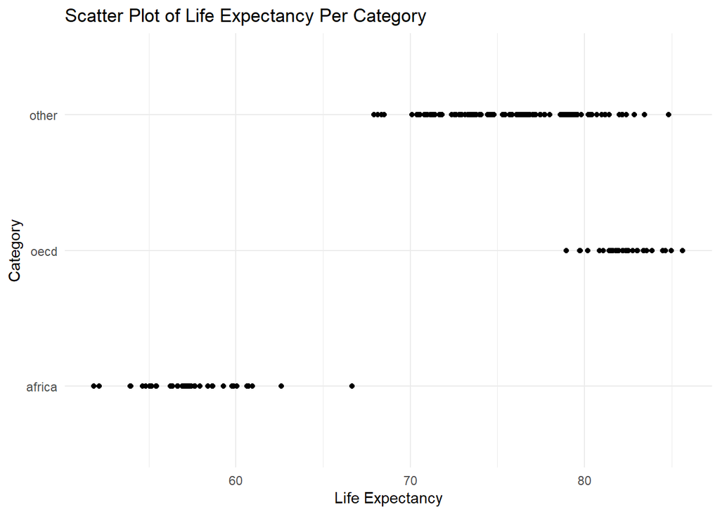

```r
ggplot(life, aes(x = LifeExp, y = Group)) +
  geom_point() +
  theme_minimal() +
  labs(x = "Life Expectancy", y = "Category", title = "Scatter Plot of Life Expectancy Per Category")
```

It seems like there’s a clear distinction in the life expectancy of the members of the three groups, with OECD countries living the longest and countries from Africa living the shortest, and the other countries in between.

#### 3. Create and print a boxplot with the response on the $y$-axis and the categorical variable on the $x$-axis. Comment on the the relationship between these two variables.

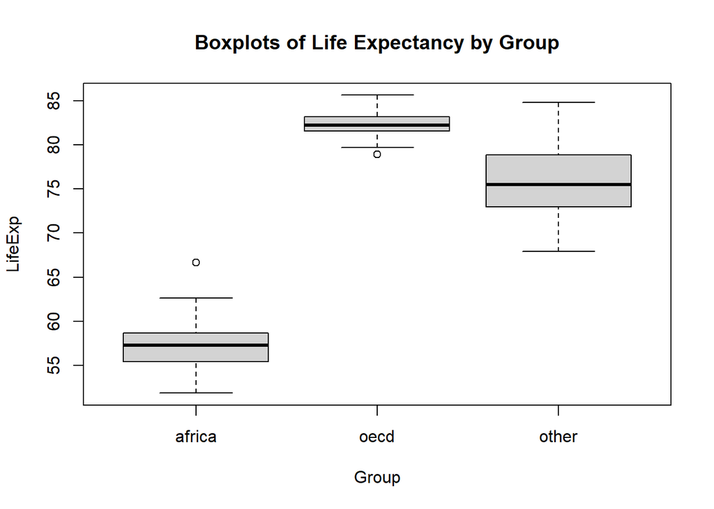

```r
boxplot(data = life, LifeExp ~ Group, main = "Boxplots of Life Expectancy by Group")
```

Similar to the last question, the OECD countries seem to be doing the best and africa seems to be doing the worst, with the other countries in between.

#### 4. Create and print a color-coded scatterplot using all of the variables that will be in your model. Hint: plot the response on the $y$-axis, the other continuous variable on the $x$-axis, and color the points by the categorical variable.

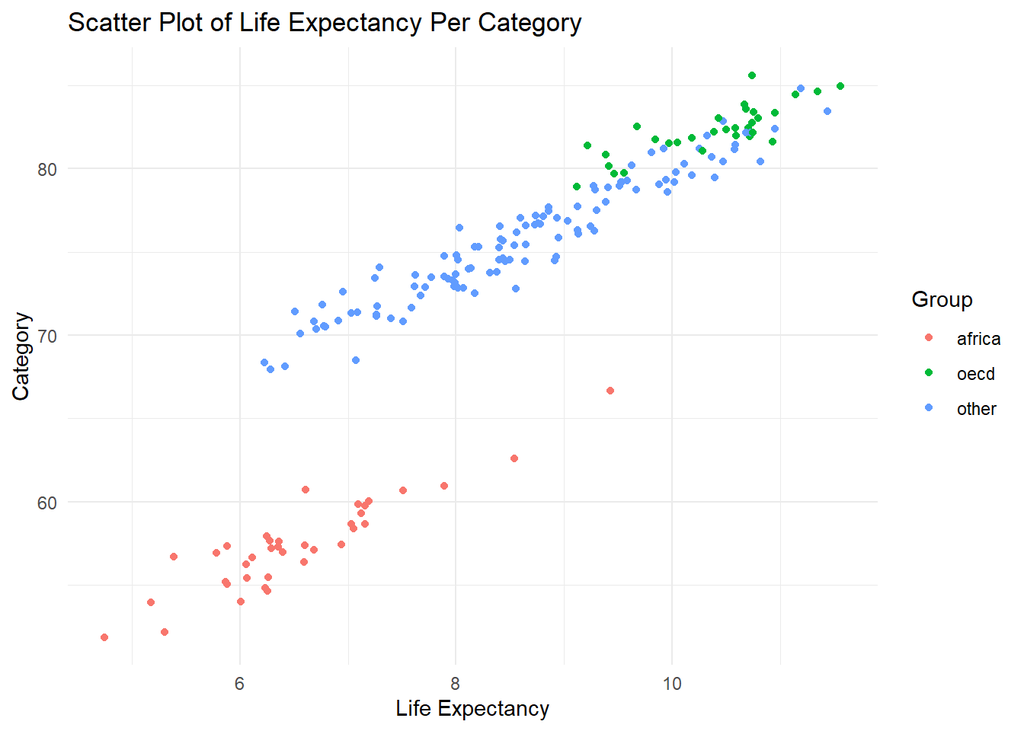

```r
ggplot(life, aes(x = PPGDP, y = LifeExp, color = Group)) +
  geom_point() +
  theme_minimal() +
  labs(x = "Life Expectancy", y = "Category", title = "Scatter Plot of Life Expectancy Per Category")
```

#### 5. Write out the theoretical model (using Greek letters/parameters) that includes main effects for Per Person GDP and the group of the country (you will not write out the fitted model using coefficients, because you have not fit a model yet). DO NOT include interactions at this step. Remember, you will need to use dummy variables for Group. **USE “other” AS THE BASELINE CATEGORY**. Use variable names that are descriptive (not $y$, $x_1$, etc.) and be sure to include proper subscripts.

$$LifeExpectancy = \beta_0 + \beta_1 PPGDP + \beta_2 I(Group = OECD) + \beta_3 I(Group = Africa) + \varepsilon$$

#### 6. Fit the multiple linear regression model from question 5 to the data (no transformations, no interactions, etc.) **using dummy variables that you create manually**. *USE “other” AS THE BASELINE CATEGORY FOR GROUP*. Display a summary of the results.

```r
life$group_africa <- ifelse(life$Group == "africa", 1, 0)
life$group_other <- ifelse(life$Group == "other", 1, 0)
life$group_oecd <- ifelse(life$Group == "oecd", 1, 0)
linear_model = lm(data = life, LifeExp ~ PPGDP + group_africa + group_oecd)
summary(linear_model)
```

```
Call:
lm(formula = LifeExp ~ PPGDP + group_africa + group_oecd, data = life)

Residuals:
    Min      1Q  Median      3Q     Max
-2.8136 -0.6546 -0.0327  0.6861  3.0454

Coefficients:
              Estimate Std. Error t value Pr(>|t|)
(Intercept)   50.95789    0.65272  78.070  < 2e-16 ***
PPGDP          2.87690    0.07478  38.470  < 2e-16 ***
group_africa -12.29427    0.25726 -47.789  < 2e-16 ***
group_oecd     1.52983    0.25418   6.019 9.88e-09 ***
---
Signif. codes:  0 '***' 0.001 '**' 0.01 '*' 0.05 '.' 0.1 ' ' 1

Residual standard error: 1.077 on 177 degrees of freedom
Multiple R-squared:  0.9857,    Adjusted R-squared:  0.9855
F-statistic:  4080 on 3 and 177 DF,  p-value: < 2.2e-16
```

#### 7. Fit the multiple linear regression model from question 5 again, but this time let R create the dummy variables for you in the lm function. As before, *USE “other” AS THE BASELINE CATEGORY FOR GROUP*. Print a summary of the results and make sure they are identical to the results from question 6.

```r
life$Group <- relevel(life$Group, ref = "other")
linear_model = lm(data = life, LifeExp ~ PPGDP + Group)
summary(linear_model)
```

```
Call:
lm(formula = LifeExp ~ PPGDP + Group, data = life)

Residuals:
    Min      1Q  Median      3Q     Max
-2.8136 -0.6546 -0.0327  0.6861  3.0454

Coefficients:
             Estimate Std. Error t value Pr(>|t|)
(Intercept)  50.95789    0.65272  78.070  < 2e-16 ***
PPGDP         2.87690    0.07478  38.470  < 2e-16 ***
Groupafrica -12.29427    0.25726 -47.789  < 2e-16 ***
Groupoecd     1.52983    0.25418   6.019 9.88e-09 ***
---
Signif. codes:  0 '***' 0.001 '**' 0.01 '*' 0.05 '.' 0.1 ' ' 1

Residual standard error: 1.077 on 177 degrees of freedom
Multiple R-squared:  0.9857,    Adjusted R-squared:  0.9855
F-statistic:  4080 on 3 and 177 DF,  p-value: < 2.2e-16
```

#### 8. Interpret the intercept. **Note that you will need to use the word “average” (or similar) twice since you are predicting an average already.** You will need to do this here and with the questions following, when interpreting.

The intercept says that the average life expectancy for a people country outside of both OECD and Africa and with a PPGDP of zero would be 50.96 years on average.

#### 9. Interpret the coefficient for PPGDP. You do not need to un-transform anything or interpret this in the percentage change framework - you can just write something like “for every one unit increase in per person GDP (log scale)” in your response.

It tells us that within each of the groups (OECD, Africa, and Other), for every one unit increase in PPGDP the life expectancy of a country increases by 2.88 years.

#### 11. Create 95% confidence intervals for all coefficients (use the `confint` function). You do not need to interpret them in this question.

```r
confint(linear_model)
```

```
                 2.5 %     97.5 %
(Intercept)  49.669772  52.246000
PPGDP         2.729321   3.024483
Groupafrica -12.801967 -11.786572
Groupoecd     1.028207   2.031453
```

#### 12. Briefly interpret the 95% confidence interval for I(Group=Africa).

This means that we can be 95% confident that the true value of the difference between average life expectancy between the African group as opposed to the “other” group falls between -12.801967 and -11.786572.

#### 13. Use the `anova` function to conduct a hypothesis test that tests a reduced model compared to the full model. Specifically, test if Group has a significant effect on LifeExp. What do you conclude from the result of the test? Hint: you will need to create another linear model and compare it with the one you made previously.

```r
anova_linear_model <- lm(data = life, LifeExp ~ Group)
anova(anova_linear_model)
```

```
Analysis of Variance Table

Response: LifeExp
           Df  Sum Sq Mean Sq F value    Pr(>F)
Group       2 12490.9  6245.4  577.95 < 2.2e-16 ***
Residuals 178  1923.5    10.8
---
Signif. codes:  0 '***' 0.001 '**' 0.01 '*' 0.05 '.' 0.1 ' ' 1
```

From this I can conclude that we can reject the null hypothesis that Group is not related to life expectancy, and that it has a statistically significant effect.

#### 14. Create a 95% prediction interval for the life expectancy of a country in the OECD with an average per person GDP (log scale) of 9.5. Print the result, and briefly interpret this interval (like we did in class). (Use the `predict` function.)

```r
new_data_point = data.frame(Group = "oecd", PPGDP = 9.5)
predict(linear_model, newdata = new_data_point, interval = "prediction", level = 0.95)
```

```
       fit      lwr      upr
1 79.81829 77.65424 81.98233
```

This means that we can be 95% confident that the actual life expectancy of a country that is in OECD with an average per person GDP (log scale) of 9.5 will fall between 77.65424 and 81.98233.

#### 15. Plot the fitted model on the scatterplot with the two continuous variables on the axes, colored by the categorical variable. Hint: you should have 3 different lines on your plot, and you will *not* need to have different line types or point shapes (you *will* need to have different colors).

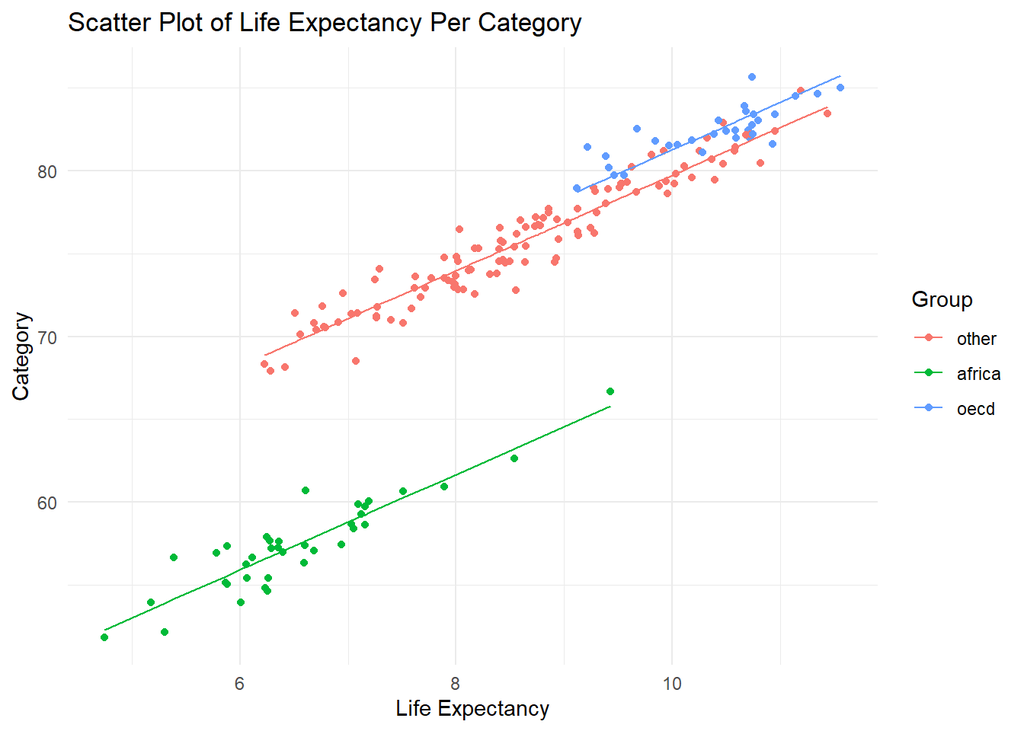

```r
# Generate predictions
life$predicted_no_interactions <- predict(linear_model)


ggplot(life, aes(x = PPGDP, y = LifeExp, color = Group)) +
  geom_point() +
  geom_line(aes(y = predicted_no_interactions)) +
  theme_minimal() +
  labs(x = "Life Expectancy", y = "Category", title = "Scatter Plot of Life Expectancy Per Category")
```

#### 16. Fit a multiple linear regression model to the data, where this time you **include an interaction term** between PPGDP and Group. *USE “other” AS THE BASELINE CATEGORY FOR GROUP*. Print a summary of the results.

```r
life$Group <- relevel(life$Group, ref = "other")
linear_model_interaction = lm(data = life, LifeExp ~ PPGDP + Group + PPGDP * Group)
summary(linear_model_interaction)
```

```
Call:
lm(formula = LifeExp ~ PPGDP + Group + PPGDP * Group, data = life)

Residuals:
    Min      1Q  Median      3Q     Max
-2.7772 -0.6729 -0.1000  0.6446  3.0438

Coefficients:
                   Estimate Std. Error t value Pr(>|t|)
(Intercept)        50.42403    0.71286  70.734  < 2e-16 ***
PPGDP               2.93882    0.08187  35.896  < 2e-16 ***
Groupafrica       -11.89511    1.47535  -8.063 1.13e-13 ***
Groupoecd          11.29201    3.21337   3.514 0.000562 ***
PPGDP:Groupafrica  -0.04128    0.21249  -0.194 0.846187
PPGDP:Groupoecd    -0.95268    0.31279  -3.046 0.002680 **
---
Signif. codes:  0 '***' 0.001 '**' 0.01 '*' 0.05 '.' 0.1 ' ' 1

Residual standard error: 1.056 on 175 degrees of freedom
Multiple R-squared:  0.9865,    Adjusted R-squared:  0.9861
F-statistic:  2551 on 5 and 175 DF,  p-value: < 2.2e-16
```

#### 17. Write out the fitted model (using coefficients values from above) for a model with PPGDP, Group, and an interaction between PPGDG and Group. Remember, you will need to use dummy variables for Group. **USE “other” AS THE BASELINE CATEGORY**. Use variable names that are descriptive (not $y$, $x_1$, etc.) and use proper subscripts.

Ask if this is formatted right

$$LifeExpectancy = 50.42403 + 2.93882 \times PPGDP + 11.29201 \times I(Group = OECD) + -11.89511 \times I(Group = Africa) +\\ -0.04128 \times PPGDP \times I(Group = Africa) + -0.95268 \times PPGDP \times I(Group = OECD)$$